# Risk Premia Algo Bootcamp - Week 1

You can execute any code chunk by clicking the *Run* button within the chunk or by placing your cursor inside it and pressing *Ctrl+Shift+Enter*.

# Data Acquisiton and Exploration

Our exploration of risk premia begins with an analysis of three broad asset classes:

- US equities
- Bonds
- Gold

In order to examine the risk premia phenomenon over a significant period of time, we are presented with some data acquisition and wrangling challenges. We’ve largely solved these for you, but it’s worth describing the process we went through as you may need to perform it independently in the future.

In most cases, we have to look further afield than a simple index-tracking ETF, since ETFs are a relatively recent phenomenon and won’t have enough price history for a decent backtest.

Instead, we can obtain data for mutual funds, which typically have been around for much longer. These funds typically pay out dividends and capital gains distributions over time. In order to understand the total return of such funds, we need to be sure to consider these dividends when constructing our price series.

We use the following mutual funds to construct price series for our various asset classes:

- VFINX, representing US equities total return index
- VBMFX, representing US bonds total return index
- GCSI Gold augmented with adjusted spot prices, representing (tradeable) Gold total return index
- VFISX, representing Treasury Bill total return index

Here’s code for loading the data and plotting the total returns of each asset class:

```r
library(xts)
library(PerformanceAnalytics)
```

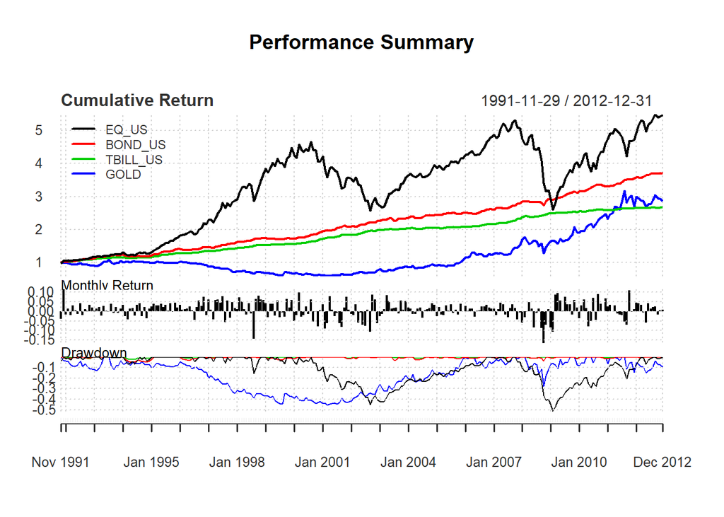

```r
read_csv_from_googledrive <- function(id, base_url="https://drive.google.com/uc?export=download&id=") {
  full_url = paste0(base_url, id)
  df =  read.csv(url(full_url), header=TRUE)

  return(df)
}


### load list object of assets and file ids from google drive
# gd_ids_url <- "https://drive.google.com/uc?export=download&id=1qoR-rKzanyH9VoQI0z25zyklVC7WSXuA"
# conn <- curl(gd_ids_url)
# gd_ids <- readRDS(conn)
# close(conn)

### create list of assets and googledrve file IDs if the above doesn't work
keys <- c("VFINX", "VBMX", "GCSI", "VFISX", "XMSC", "MXEA", "BEGBX", "PREMX")
values <- c("1i520xsTTFkz0hwpV43NuoXWv4tA3j8yi",
            "14w82iU2f6yUCwpj97ivxwSZqufcYZp95",
            "178Zoz7pYrrAm1uGQ1B9tRy-BkzY3VCCH",
            "10A00Ig3SdCMOqdz9X9M6ZY5ttDkCQkge",
            "1ceZfqCPzKXx0rhlSAPFAiR8OBPXTn6-N",
            "1UPEaoxehnNjaWuVbd8KvXVuXM2PW6AAt",
            "1hU4hdskeHckCAVt9amQ_ZSUzChwW3Jbb",
            "1NhKF7KZDwn3F_WPAdtxXjq56VbzCe2Rl")
gd_ids <- list()
for(i in 1:length(keys)) {
  gd_ids[[keys[i]]] <- values[i]
}

# US Equity total return index generated from VFINX mutual fund prices
EQ_US_df <- read_csv_from_googledrive(gd_ids$VFINX)
EQ_US <- as.xts(EQ_US_df$Cum_Return, order.by = as.Date(EQ_US_df[,1]))

# US Bond total return index generated from VBMFX mutual fund prices
BOND_US_df <- read_csv_from_googledrive(gd_ids$VBMX)
BOND_US <- as.xts(BOND_US_df$Cum_Return, order.by = as.Date(BOND_US_df[,1]))

# Gold total return index generated by extending GSCI Gold index back with Gold spot prices
GOLD_df <- read_csv_from_googledrive(gd_ids$GCSI)
GOLD <- as.xts(GOLD_df$Cum_Ret, order.by = as.Date(GOLD_df[,1]))

# Treasury bill returns from VFISX mutual fund prices
TBILL_US_df <- read_csv_from_googledrive(gd_ids$VFISX)
TBILL_US <- as.xts(TBILL_US_df$Cum_Return, order.by = as.Date(TBILL_US_df[,1]))

# Merge data for plotting
# GOLD series has observations on days the mututal funds did not trade and vice versa.
# We decide to deal with this by  left joining the gold series to the combined equity and bond series
# and carrying forward any NAs in the GOLD series.
index <- na.omit(na.locf(merge(merge(EQ_US, BOND_US, TBILL_US), GOLD, join = 'left')))
colnames(index) <- c('EQ_US','BOND_US', 'TBILL_US', 'GOLD')

# Keep data from 2013 aside. (Note it's not a very good OOS period, as we know what happened!)
sample <- index['::2012']

# Calculate daily, weekly and monthly discrete returns
returns_daily <- na.omit(Return.calculate(sample, method = 'discrete'))
returns_weekly <- na.omit(Return.calculate(sample[endpoints(sample, on='weeks')], method = 'discrete'))
returns_monthly <- na.omit(Return.calculate(sample[endpoints(sample, on='months')], method = 'discrete'))

charts.PerformanceSummary(returns_monthly, wealth.index = TRUE, legend.loc = 'topleft'
                          , main = 'Performance Summary')
```

Next, we compare the return distribution of the various assets. We are interested in various characteristics such as the mean return, the spread of returns, as well as any skew in the frequency or magnitude of positive vs negative returns.

To accomplish ths, we could plot return histograms for each asset and compare them. Another way is to plot returns using a box plot, also known as a box and whiskers plot. These plots are very useful to have in your arsenal, as they provide a rich breadth of information in a single glance.

The code below creates the box plots for the returns of each of our asset. Here’s how to interpret these plots:

- The edges of the ‘box’ indicates the interquartile range, which covers the 25th to 75th percentiles.
- The vertical line inside the box indicates the median value, that is, the value for which 50% of values are larger, and 50% are smaler.
- The red dot indicates the mean value.
- The ‘whiskers’ extending to the left and right of the box indicate the 95th and 5th percentiles.
- Any points lying outside the ‘whiskers’ are plotted to alert you to the presence and impact of potential outliers.

So, what can we say about our various assets given the box plots below?

- Firstly, they all have a positive mean, indicating that they did indeed “go up”.
- The spreads of equities and gold returns are much greater than those of bonds and t-bills. This is indicative of the vastly different volatilities of these different assets.
- You can see that the mean return of equities was higher than for bonds and t-bills. Under the risk premia paradim, this higher return is the equities investor’s reward for taking on the greater risk (which we can infer from the greater spread in equities returns).
- Can you say the same thing for gold?
- Look at the extreme negative values for equities: there are several negative returns that lie outside the 5th percentile, but there are no extreme positive returns that lie outside the 95th percentile. This is indicative of the tendency of equities to have greater downside volatility than upside volatility. Does this hold true for the other assets?

The box plot does have its limitations (for instance, it says nothing about the size of a data set, and different distributions can actually generate identical box plots), but for quick yet revealing comparisons like the one we’ve just done here, they are hard to beat.

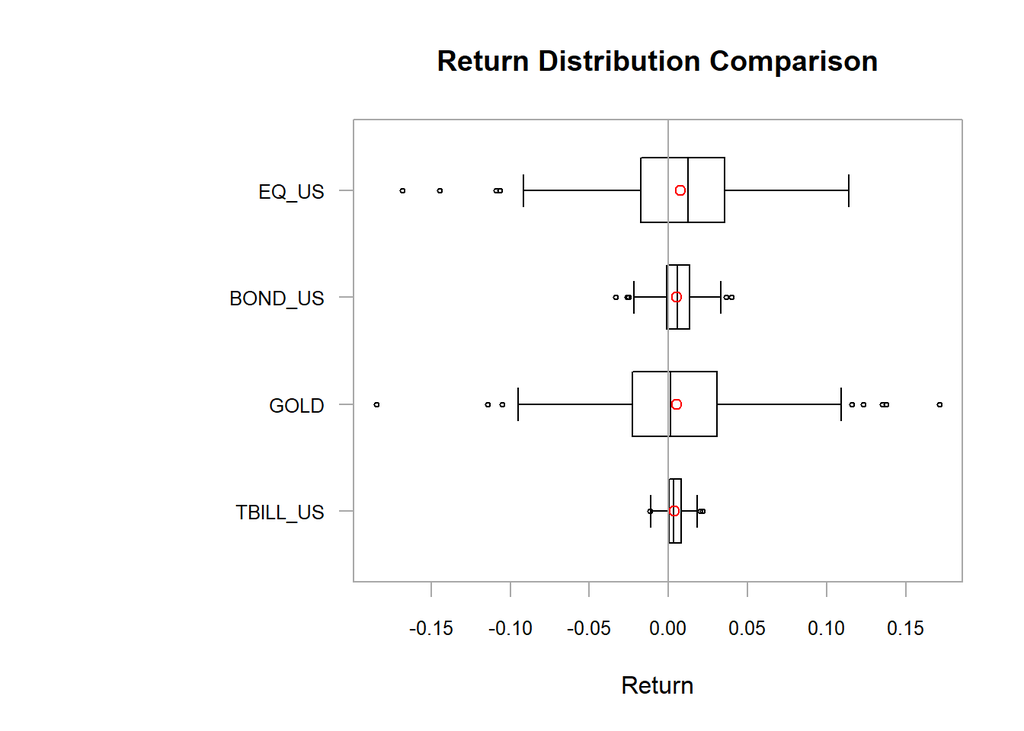

```r
chart.Boxplot(returns_monthly)
```

Next we look at some summary statistics for our different assets. What we see here is reflected in the box plots above. Take particular note of the return vs standard deviation of each asset, which is a decent proxy for the concept of risk vs reward.

```r
table.AnnualizedReturns(returns_monthly)
```

```
##                            EQ_US BOND_US TBILL_US   GOLD
## Annualized Return         0.0836  0.0638   0.0474 0.0511
## Annualized Std Dev        0.1500  0.0369   0.0211 0.1565
## Annualized Sharpe (Rf=0%) 0.5572  1.7286   2.2502 0.3261
```

It is also helpful to look more closely at the downside returns. There are some terms in the table below that you might not have seen before:

- Semi deviation is the standard deviation of a subset consisting of returns less than the mean return.
- Gain and loss deviation are the standard deviations of of the positive and negative returns respectively. What you’re looking for here is any difference between the two, which is indicative of different returns profiles to the upside and the downside.
- Downside deviation again subets the data, this time based on some return threshold.
- VaR (value at risk) is the 95th percentile return
- ES (expected shortfall) is the average of all losses that exceed the VaR.

```r
table.DownsideRisk(returns_monthly)
```

```
##                                EQ_US BOND_US TBILL_US    GOLD
## Semi Deviation                0.0328  0.0078   0.0042  0.0306
## Gain Deviation                0.0247  0.0071   0.0046  0.0323
## Loss Deviation                0.0316  0.0067   0.0032  0.0266
## Downside Deviation (MAR=10%)  0.0331  0.0095   0.0071  0.0324
## Downside Deviation (Rf=0%)    0.0291  0.0053   0.0024  0.0278
## Downside Deviation (0%)       0.0291  0.0053   0.0024  0.0278
## Maximum Drawdown              0.5097  0.0499   0.0241  0.4571
## Historical VaR (95%)         -0.0715 -0.0117  -0.0057 -0.0601
## Historical ES (95%)          -0.0974 -0.0189  -0.0091 -0.0856
## Modified VaR (95%)           -0.0696 -0.0127  -0.0059 -0.0650
## Modified ES (95%)            -0.1023 -0.0195  -0.0084 -0.0882
```

Auto-correlation refers to the correlation of a time series with lagged values of itself. Positive autocorrelation implies that past values are corelated with future values, while negative autocorrelation implies that past values are anti-correlated with future values. There is lots of material about autocorrelation and correlograms (plots of autocorrelation over various lags) in the advanced course.

Here we see no significant autocorrelation at any lag for monthly equities and bonds returns, and barely-significant autocorrelation for gold returns. Dam! If only trading were that easy.

Looking at daily returns, we see more instances of slightly significant autocorrelation. Two major things to consider when looking at plots like these:

- If we’re using a significance level of 5%, we expect to see one in twenty data points seemingly significant by chance alone.
- We are looking here at a lot of data, in aggregate. We were very intrigued by what we saw in the autocorrelation of the daily bonds data in particular, which shows some regular, significant peaks and troughs. Looking more closely, we investigated how autocorrelation has changd with time. We found that the peaks and troughs we see in the chart below are due to characteristics of the bond market in the 80s and 90s, before tools such as the one we’re using now became the standard way to analyse the market. If you look at more recent bond data, the correlogram looks a lot more random. We encourage you to explore this for yourself!

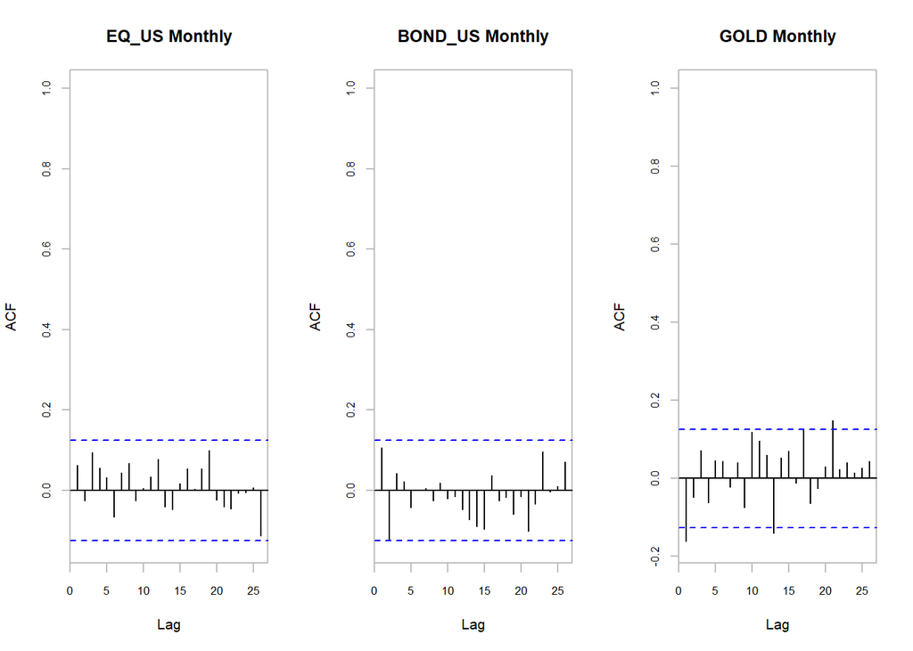

```r
par(mfrow=c(1,3))
chart.ACF(returns_monthly$EQ_US, main=c('EQ_US Monthly'))
chart.ACF(returns_monthly$BOND_US, main=c('BOND_US Monthly'))
chart.ACF(returns_monthly$GOLD, main=c('GOLD Monthly'))
```

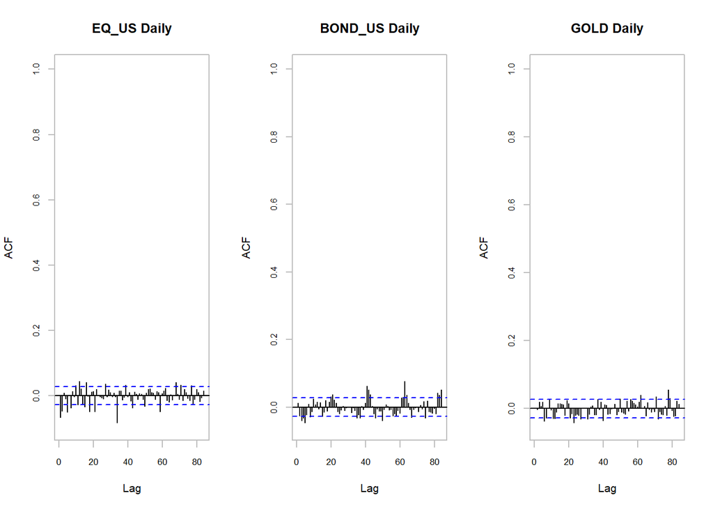

```r
par(mfrow=c(1,3))
chart.ACF(returns_daily$EQ_US, main=c('EQ_US Daily'))
chart.ACF(returns_daily$BOND_US, main=c('BOND_US Daily'))
chart.ACF(returns_daily$GOLD, main=c('GOLD Daily'))
```

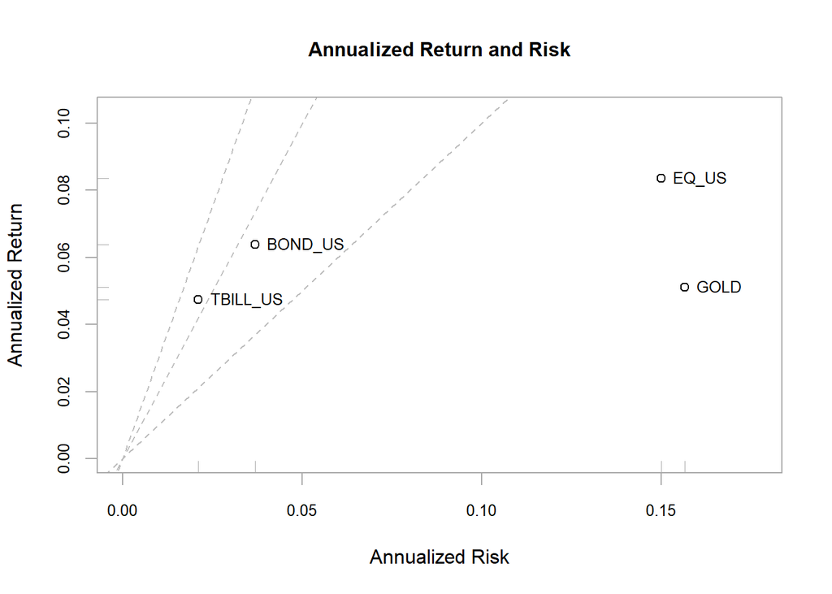

```r
chart.RiskReturnScatter(returns_monthly)
```

Next we explore rolling performance. So far, we’ve only looked at our data in aggregate, but looking at how it changes through time is very important too, and often reveals insights that weren’t apparent from the aggregate data. Here we use a rolling 12-month window when calculating performance, but you’re encouraged to use several window lengths and compare them.

Here the greater volatility of equities and gold compared with bonds is readily apparent as we see rolling performance fluctuate through much wider ranges.

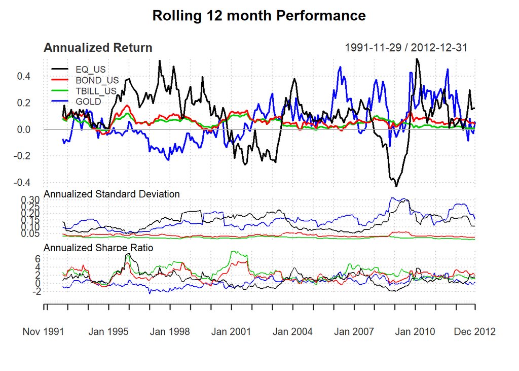

```r
charts.RollingPerformance(returns_monthly, width = 12, legend.loc = 'topleft')
```

Likewise we look at rolling correlations. Again this should give you pause when considering a single value for a statistic such as correlation - it really represents nothing more than a snapshot in time. Look how much correlations have changed over the years!

This is important, because correlation is one of the drivers for a number of portfolio construction and optimisation techniques. What do you think might be the implications of assuming a static correlation between assets?

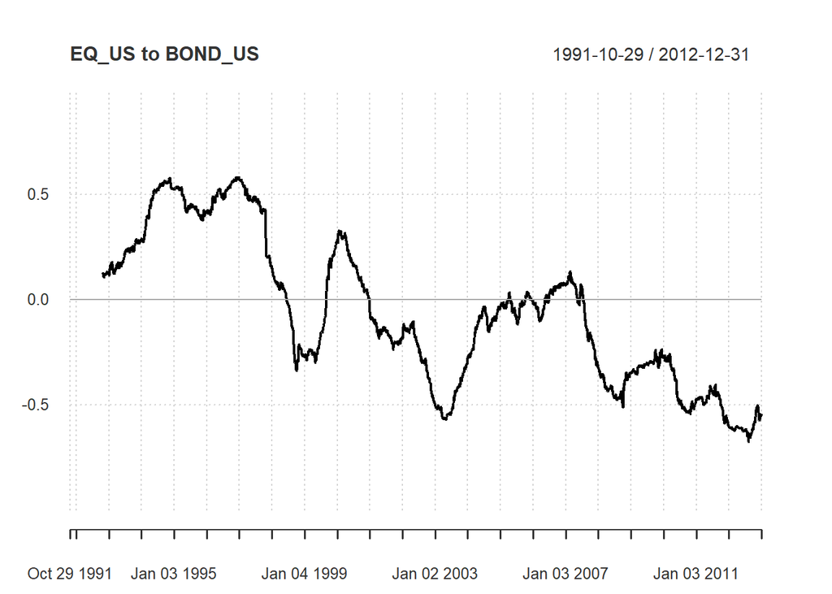

```r
chart.RollingCorrelation(returns_daily[,1], returns_daily[,2], width = 252)
```

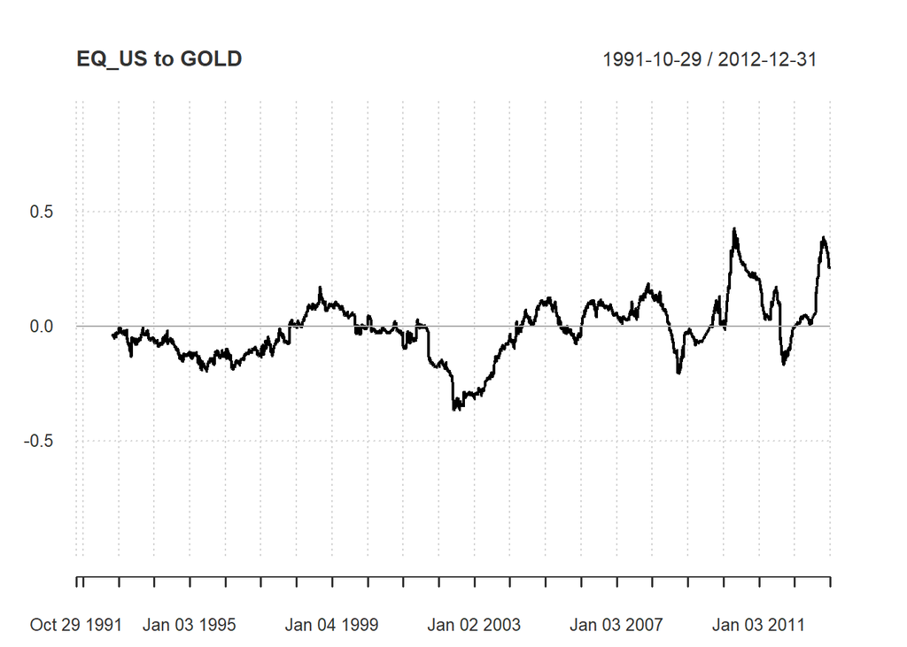

```r
chart.RollingCorrelation(returns_daily[,1], returns_daily[,4], width = 252)
```

Finally, we come to the fun stuff: constructing a portfolio of our assets and finding out how it would have performed.

Here we construct the simplest possble portfolio - the equal weight portfolio (you might also hear this referred to as the one-on-n portfolio, since it involves allocating 1/n of your portfolio to each of n assets), rebalanced monthly to maintain the equal weight scheme.

Are you surprised to learn that the equal weight portfolio returned over 250% in the 20-odd years between 1991 and 2012? Doesn’t seem too shabby for something that requires next to no effort to maintain!

But be careful - have we simply created a portfolio from assets that we knew went up a decent amount in the time period investigated? Can we have any confidence in the continuation of such performance? Below we’ll throw in some different assets, such as international equities, and compare performance.

Notwithstanding the above, we believe that it’s generally a good idea to be long risk premia, especially when your investment horizon is long. However, you might be surprised to learn that the equal weight portfolio can be quite tricky to outperform. And even trickier when you want to get a return that matches the effort required to construct fancier portfolios! We’ll explore this in more detail throughout the bootcamp.

```r
EW_portfolio <- Return.portfolio(returns_monthly, weights = c(0.25,0.25,0.25,0.25), rebalance_on = 'months')
EW_compare <- merge(EW_portfolio, returns_monthly[,'EQ_US'], join='left')
table.AnnualizedReturns(EW_compare)
```

```
##                           portfolio.returns  EQ_US
## Annualized Return                    0.0660 0.0836
## Annualized Std Dev                   0.0579 0.1500
## Annualized Sharpe (Rf=0%)            1.1397 0.5572
```

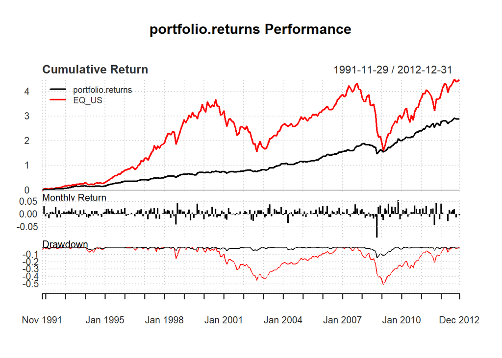

```r
charts.PerformanceSummary(EW_compare)
```

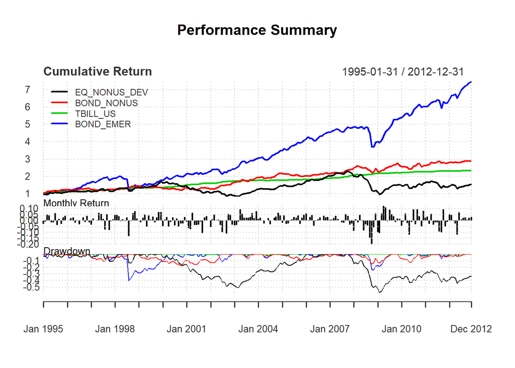

```r
# Non-US Developed Markets Equity total return index generated from XMSC MSCI index prices
EQ_NONUS_DEV_df <- read_csv_from_googledrive(gd_ids$XMSC)
EQ_NONUS_DEV <- as.xts(EQ_NONUS_DEV_df$Cum_Return, order.by = as.Date(EQ_NONUS_DEV_df[,1]))

# Emerging Markets Equity total return index generated from MXEA MSCI index prices
EQ_EMER_df <- read_csv_from_googledrive(gd_ids$MXEA)
EQ_EMER <- as.xts(EQ_EMER_df$Cum_Return, order.by = as.Date(EQ_EMER_df[,1]))

# International Bonds total return index generated from Benham International Bond Fund prices
BOND_NONUS_df <- read_csv_from_googledrive(gd_ids$BEGBX)
BOND_NONUS <- as.xts(BOND_NONUS_df$Cum_Return, order.by = as.Date(BOND_NONUS_df[,1]))

# Emerging Markets Bond total return index generated from T Rowe Price Emerging Markets Bond Fund
BOND_EMER_df <- read_csv_from_googledrive(gd_ids$PREMX)
BOND_EMER <- as.xts(BOND_EMER_df$Cum_Return, order.by = as.Date(BOND_EMER_df[,1]))

# Merge data for plotting
nonus_index <- na.omit(na.locf(merge(EQ_NONUS_DEV, BOND_NONUS, TBILL_US, BOND_EMER )))

# Keep data from 2013 aside. (Note it's not a very good OOS period, as we know what happened!)
nonus_sample <- nonus_index['::2012']

# Calculate daily, weekly and monthly discrete returns
nonus_returns_monthly <- na.omit(Return.calculate(nonus_sample[endpoints(nonus_sample, on='months')], method = 'discrete'))

charts.PerformanceSummary(nonus_returns_monthly, wealth.index = TRUE, legend.loc = 'topleft'
                          , main = 'Performance Summary')
```

```r
nonus_EW_portfolio <- Return.portfolio(nonus_returns_monthly, weights = c(0.25,0.25,0.25,0.25), rebalance_on = 'months')
table.AnnualizedReturns(nonus_EW_portfolio)
```

```
##                           portfolio.returns
## Annualized Return                    0.0672
## Annualized Std Dev                   0.0789
## Annualized Sharpe (Rf=0%)            0.8516
```

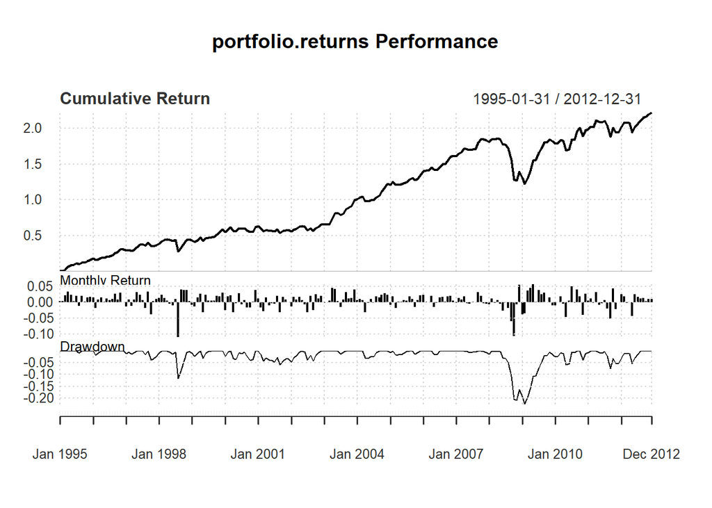

```r
charts.PerformanceSummary(nonus_EW_portfolio)
```